# Statistique-python

Test d'indépendance 🎲 avec Python

Les tests d'indépendance permettent de définir s'il existe un lien entre deux variables. Il existe différents tests d'indépendance, en voici quelques exemples :

- Test d'indépendance entre deux variables quantitatives / Test de corrélation Pearson
- Test d'indépendance entre deux variables qualitatives / Test du Chi²
- Test d'indépendance entre une variable qualitative et une quantitative / Test de Fisher avec l'analyse de la variance (ANOVA)

Dans une démarche d'un projet de machine learning, les test d'indépendance permettent d'exclure des variables explicatives potentiellement non porteuses d'information.

Librairies utilisées

```python
# Importation de la bibliothèque de traçage Matplotlib
import matplotlib.pyplot as plt

# Importation de la bibliothèque Seaborn pour une visualisation de données plus attrayante
import seaborn as sns

# Importation de la bibliothèque NumPy pour le support de tableaux et de matrices multidimensionnels
import numpy as np

# Importation de la bibliothèque Pandas pour la manipulation et l'analyse des données
import pandas as pd

# Importation de divers modules de statistiques de la bibliothèque SciPy
from scipy.stats import pearsonr   # Corrélation de Pearson
from scipy.stats import bartlett   # Test de Bartlett pour l'homoscédasticité
from scipy.stats import shapiro    # Test de normalité de Shapiro
from scipy.stats import chi2_contingency  # Test du chi2 pour l'indépendance entre variables catégorielles
from scipy.stats import kendalltau, spearmanr  # Corrélations de Kendall et de Spearman

# Importation de modules de prétraitement de données de la bibliothèque scikit-learn
from sklearn.preprocessing import StandardScaler  # Standardisation des caractéristiques
from sklearn.datasets import make_regression, make_circles  # Génération de jeux de données pour la régression et la classification

# Importation de modules de statistiques de la bibliothèque Statsmodels
import statsmodels.stats.multicomp as multi  # Comparaisons multiples avec ajustement de Bonferroni
import statsmodels.api as sm  # Modèles statistiques avancés
from statsmodels.formula.api import ols  # Modèle linéaire ordinaire
```

# Test de corrélation Pearson

L’intérêt des tests de corrélation est d’apporter plus de pertinence et de fiabilité aux coefficients de corrélation. Il existe différents tests de corrélation, nous utilisons celui de Pearson.

On travaille avec le jeu de données fromage 🧀 disponible en [cliquant ici](https://github.com/asardell/statistique-python/tree/master/Dataset)

```python
# Chargement d'un fichier texte dans un DataFrame Pandas en utilisant read_table
# Documentation Pandas pour read_table: https://pandas.pydata.org/pandas-docs/stable/reference/api/pandas.read_table.html
df = pd.read_table("../Dataset/fromage.txt", index_col=0)

# Affichage des premières lignes du DataFrame pour vérifier les données
# Documentation Pandas pour head: https://pandas.pydata.org/pandas-docs/stable/reference/api/pandas.DataFrame.head.html
df.head()
```

| Fromages | calories | sodium | calcium | lipides | retinol | folates | proteines | cholesterol | magnesium |
| --- | --- | --- | --- | --- | --- | --- | --- | --- | --- |
| CarredelEst | 314 | 353.5 | 72.6 | 26.3 | 51.6 | 30.3 | 21.0 | 70 | 20 |
| Babybel | 314 | 238.0 | 209.8 | 25.1 | 63.7 | 6.4 | 22.6 | 70 | 27 |
| Beaufort | 401 | 112.0 | 259.4 | 33.3 | 54.9 | 1.2 | 26.6 | 120 | 41 |
| Bleu | 342 | 336.0 | 211.1 | 28.9 | 37.1 | 27.5 | 20.2 | 90 | 27 |
| Camembert | 264 | 314.0 | 215.9 | 19.5 | 103.0 | 36.4 | 23.4 | 60 | 20 |

Avant de réaliser des tests d'indépendance, on projette graphiquement les données 2 à 2

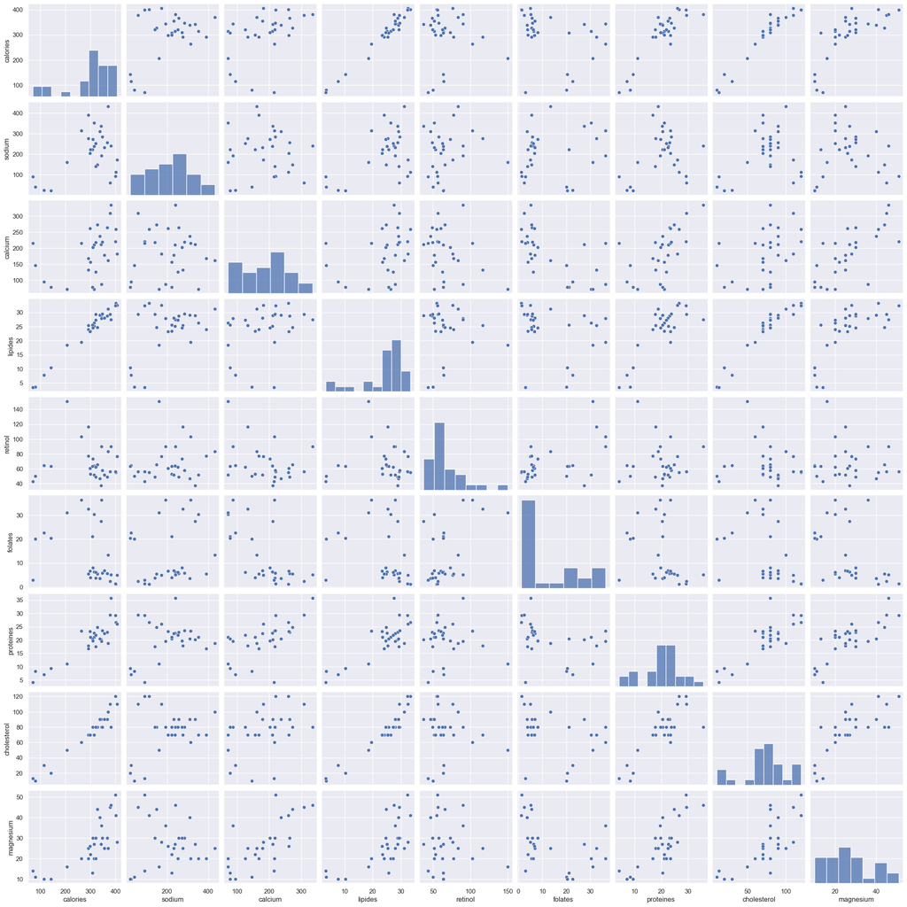

```python
# Utilisation de Seaborn pour créer une matrice de nuages de points (pairplot) pour les colonnes 0 à 8 du DataFrame
# Documentation Seaborn pour pairplot: https://seaborn.pydata.org/generated/seaborn.pairplot.html
# Sélection de toutes les lignes du DataFrame df, mais uniquement les colonnes des indices 0 à 8
# Utilisation de la méthode iloc pour l'indexation basée sur des positions
# La syntaxe iloc[:, 0:9] signifie toutes les lignes (:), et les colonnes de l'indice 0 inclus à l'indice 8 inclus (0:9)
# Documentation Pandas pour iloc: https://pandas.pydata.org/pandas-docs/stable/reference/api/pandas.DataFrame.iloc.html
sns.pairplot(df.iloc[:, 0:9])
```

## Matrice des corrélations

Voici la matrice des corrélations des variables du fichier fromage.

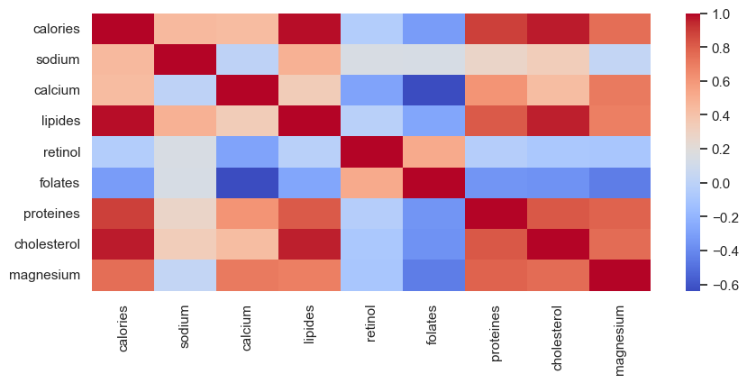

```python
# Définition de la taille par défaut des figures pour les tracés Seaborn
# Documentation Seaborn pour sns.set: https://seaborn.pydata.org/generated/seaborn.set.html
# Configuration de la taille par défaut des figures (plots) créées par Seaborn
# Utilisation de sns.set pour définir les paramètres esthétiques (rc) de la figure.figsize
# La taille est définie ici sur (10, 4) pouces (largeur, hauteur)
# Documentation Seaborn pour sns.set: https://seaborn.pydata.org/generated/seaborn.set.html
sns.set(rc={'figure.figsize':(10,4)})

# Calcul de la matrice de corrélation pour le DataFrame df
# Documentation Pandas pour corr: https://pandas.pydata.org/pandas-docs/stable/reference/api/pandas.DataFrame.corr.html
df_corr = df.corr()

# Création d'une heatmap (carte thermique) à partir de la matrice de corrélation avec Seaborn
# Documentation Seaborn pour heatmap: https://seaborn.pydata.org/generated/seaborn.heatmap.html
# Création d'une heatmap à partir de la matrice de corrélation df_corr avec Seaborn
# Utilisation de sns.heatmap pour visualiser graphiquement la corrélation entre les variables
# xticklabels et yticklabels sont utilisés pour afficher les étiquettes des colonnes sur les axes x et y respectivement
# cmap='coolwarm' définit la palette de couleurs utilisée dans la heatmap
# Documentation Seaborn pour heatmap: https://seaborn.pydata.org/generated/seaborn.heatmap.html
ax = sns.heatmap(df_corr, xticklabels=df_corr.columns, yticklabels=df_corr.columns, cmap='coolwarm')
```

L'intérêt des tests de corrélation est d'apporter plus de pertinence et fiabilité aux coefficients de corrélation. Il existe différents test de corrélation, nous utilisons celui de Pearson.

```python
# Importation de la fonction pearsonr du module scipy.stats
# La fonction pearsonr est utilisée pour calculer la corrélation de Pearson et son p-value
# Documentation SciPy pour pearsonr: https://docs.scipy.org/doc/scipy/reference/generated/scipy.stats.pearsonr.html
from scipy.stats import pearsonr
```

On pose les hypothèses de départ :

- H0 : Variables indépendantes si p-value > 5%
- H1 : Variables non indépendantes si p-value < 5%

### Lipides vs Magnesium

La première sortie correspond au coefficient de corrélation, la seconde à la p-value (ou probabilité critique)

```python
# Calcul de la corrélation de Pearson entre les colonnes 'lipides' et 'magnesium' du DataFrame df
# Utilisation de la fonction pearsonr du module scipy.stats
# La fonction pearsonr renvoie un tuple contenant le coefficient de corrélation de Pearson et la valeur p associée
# Documentation SciPy pour pearsonr: https://docs.scipy.org/doc/scipy/reference/generated/scipy.stats.pearsonr.html

pearsonr(df.lipides, df.magnesium)
```

```
PearsonRResult(statistic=0.6898600757996967, pvalue=3.4693640122029244e-05)
```

~H0 : Variables indépendantes si p-value > 5%~  
H1 : Variables non indépendantes si p-value < 5%

### Sodium vs Retinol

```python
# Calcul de la corrélation de Pearson entre les colonnes 'sodium' et 'retinol' du DataFrame df
# Utilisation de la fonction pearsonr du module scipy.stats
# La fonction pearsonr renvoie un tuple contenant le coefficient de corrélation de Pearson et la valeur p associée
# Documentation SciPy pour pearsonr: https://docs.scipy.org/doc/scipy/reference/generated/scipy.stats.pearsonr.html

pearsonr(df.sodium, df.retinol)
```

```
PearsonRResult(statistic=0.14432755157345512, pvalue=0.45508547512205944)
```

H0 : Variables indépendantes si p-value > 5%  
~H1 : Variables non indépendantes si p-value < 5%~  
Si on veut rejeter H0 et prendre H1, on a 45,5% de chance de se tromper

📢 Les tests statistiques sont très sensibles à la taille de l'échantillon. Un coefficient de corrélation de 0.14 n'aura pas la même significativité sur un échantillon de 29 fromages qu'un échantillon de 319 fromages avec le même coefficient de corrélation.

On construit un dataframe en dupliquant le nombre de lignes

```python
# Création d'une copie du DataFrame df
df_append = df.copy()

# Réinitialisation de l'index du DataFrame
# Utilisation de la méthode reset_index pour remettre l'index du DataFrame à sa forme originale
# inplace=True modifie le DataFrame existant au lieu de créer une copie
# Documentation Pandas pour reset_index: https://pandas.pydata.org/pandas-docs/stable/reference/api/pandas.DataFrame.reset_index.html
df_append.reset_index(inplace=True)

# Append du DataFrame copié à lui-même 10 fois, en ignorant l'index pour éviter les duplicatas
# Utilisation de la méthode append de Pandas pour concaténer plusieurs copies du DataFrame
# ignore_index=True réinitialise l'index du DataFrame résultant
# Documentation Pandas pour append: https://pandas.pydata.org/pandas-docs/stable/reference/api/pandas.DataFrame.append.html
df_append = df_append._append([df_append]*10, ignore_index=True)

# Affichage de la forme (nombre de lignes et de colonnes) du DataFrame résultant
# Utilisation de la propriété shape pour obtenir les dimensions du DataFrame
df_append.shape
```

```
(319, 10)
```

Chaque fromage apparaît plusieurs fois, on a donc augmenté la taille de l'échantillon

```python
# Utilisation de la méthode value_counts() pour compter le nombre d'occurrences de chaque valeur dans la colonne 'Fromages'
# Cela génère une série Pandas avec les valeurs uniques comme index et leur fréquence comme valeurs
# Documentation Pandas pour value_counts: https://pandas.pydata.org/pandas-docs/stable/reference/api/pandas.Series.value_counts.html

# Utilisation de la méthode head() pour afficher les premières lignes de la série (par défaut, les 5 premières)
# Ceci donne un aperçu des fromages les plus fréquemment présents dans le DataFrame
# Documentation Pandas pour head: https://pandas.pydata.org/pandas-docs/stable/reference/api/pandas.Series.head.html

df_append.Fromages.value_counts().head()
```

```
Fromages
CarredelEst       11
Fr.frais20nat.    11
Vacherin          11
Tome              11
SaintPaulin       11
Name: count, dtype: int64
```

On effectue un autre test de corrélation avec les mêmes variables sur l'échantillon plus grand

```python
# Calcul de la corrélation de Pearson entre les colonnes 'sodium' et 'retinol' du DataFrame df_append
# Utilisation de la fonction pearsonr du module scipy.stats
# La fonction pearsonr renvoie un tuple contenant le coefficient de corrélation de Pearson et la valeur p associée
# Documentation SciPy pour pearsonr: https://docs.scipy.org/doc/scipy/reference/generated/scipy.stats.pearsonr.html

pearsonr(df_append.sodium, df_append.retinol)
```

```
PearsonRResult(statistic=0.1443275515734551, pvalue=0.00984628928803309)
```

~H0 : Variables indépendantes si p-value > 5%~  
H1 : Variables non indépendantes si p-value < 5%

On obtient logiquement le même coefficient de corrélation, mais en revanche, cette fois si la p-value est proche de 0.

### Matrice des p-values

On effectue un test de corrélation sur chaque variable 2 à 2 en isolant uniquement la p-value

```python
# Création d'un tableau numpy de dimensions (nombre de colonnes, nombre de colonnes)
# Initialisation avec des valeurs NaN
a = np.empty((len(df.columns), len(df.columns),))
a[:] = np.nan

# Boucle pour calculer les valeurs p (p-value) de la corrélation de Pearson entre toutes les paires de colonnes du DataFrame df
for i in range(0, len(df.columns)):
    for j in range(0, len(df.columns)):
        # Utilisation de la fonction pearsonr du module scipy.stats pour calculer le coefficient de corrélation de Pearson et la valeur p
        # La valeur p est stockée dans la deuxième position du tuple retourné par pearsonr, d'où [1]
        a[i, j] = pearsonr(df.iloc[:, i], df.iloc[:, j])[1]

# Création d'un DataFrame Pandas à partir du tableau numpy contenant les valeurs p
# Arrondissement des valeurs à 6 décimales
df_pvalue = round(pd.DataFrame(a, columns=df.columns, index=df.columns), 6)
```

On affiche la matrice des corrélations avec un gradiant de couleur

```python
# Création d'une palette de couleurs à partir de la couleur "green" avec la fonction light_palette de Seaborn
# La palette sera utilisée pour la coloration de fond dans le style du DataFrame
# Documentation Seaborn pour light_palette: https://seaborn.pydata.org/generated/seaborn.light_palette.html
cm = sns.light_palette("green", as_cmap=True)

# Arrondissement des valeurs du DataFrame df_pvalue à 2 décimales
df_pvalue = df_pvalue.round(2)

# Application d'une coloration de fond gradient à partir de la palette de couleurs définie
# Utilisation de la méthode background_gradient du style Pandas DataFrame
# Cette méthode applique une coloration de fond en fonction des valeurs du DataFrame
# Documentation Pandas pour background_gradient: https://pandas.pydata.org/pandas-docs/stable/user_guide/style.html#Building-styles
df_pvalue.style.background_gradient(cmap=cm)
```

|  | calories | sodium | calcium | lipides | retinol | folates | proteines | cholesterol | magnesium |
| --- | --- | --- | --- | --- | --- | --- | --- | --- | --- |
| calories | 0.000000 | 0.010000 | 0.020000 | 0.000000 | 0.830000 | 0.090000 | 0.000000 | 0.000000 | 0.000000 |
| sodium | 0.010000 | 0.000000 | 0.980000 | 0.010000 | 0.460000 | 0.480000 | 0.150000 | 0.080000 | 0.870000 |
| calcium | 0.020000 | 0.980000 | 0.000000 | 0.070000 | 0.130000 | 0.000000 | 0.000000 | 0.020000 | 0.000000 |
| lipides | 0.000000 | 0.010000 | 0.070000 | 0.000000 | 0.920000 | 0.150000 | 0.000000 | 0.000000 | 0.000000 |
| retinol | 0.830000 | 0.460000 | 0.130000 | 0.920000 | 0.000000 | 0.000000 | 0.840000 | 0.650000 | 0.610000 |
| folates | 0.090000 | 0.480000 | 0.000000 | 0.150000 | 0.000000 | 0.000000 | 0.060000 | 0.050000 | 0.020000 |
| proteines | 0.000000 | 0.150000 | 0.000000 | 0.000000 | 0.840000 | 0.060000 | 0.000000 | 0.000000 | 0.000000 |
| cholesterol | 0.000000 | 0.080000 | 0.020000 | 0.000000 | 0.650000 | 0.050000 | 0.000000 | 0.000000 | 0.000000 |
| magnesium | 0.000000 | 0.870000 | 0.000000 | 0.000000 | 0.610000 | 0.020000 | 0.000000 | 0.000000 | 0.000000 |

💡 Obtient-on les mêmes p-value si on centre et on réduit ?

On centre et on réduit

```python
# Importation de la classe StandardScaler depuis le module preprocessing de scikit-learn
from sklearn.preprocessing import StandardScaler

# Création d'une instance de StandardScaler, qui sera utilisée pour normaliser les données
scaler = StandardScaler()

# Application de la transformation de normalisation aux données du DataFrame df
# fit_transform ajuste le scaler aux données et normalise celles-ci simultanément
# Le résultat est un tableau NumPy contenant les données normalisées
df_CR = scaler.fit_transform(df)

# Création d'un nouveau DataFrame à partir des données normalisées
# Les colonnes du DataFrame original df sont conservées, et les données sont étiquetées avec les mêmes noms de colonnes
df_CR = pd.DataFrame(df_CR, columns=df.columns)

# Affichage des trois premières lignes du DataFrame normalisé
df_CR.head(3)
```

|  | calories | sodium | calcium | lipides | retinol | folates | proteines | cholesterol | magnesium |
| --- | --- | --- | --- | --- | --- | --- | --- | --- | --- |
| 0 | 0.154630 | 1.342968 | -1.587464 | 0.268066 | -0.672290 | 1.500911 | 0.121519 | -0.165242 | -0.626309 |
| 1 | 0.154630 | 0.261393 | 0.337679 | 0.117846 | -0.162662 | -0.573843 | 0.355480 | -0.165242 | 0.003101 |
| 2 | 1.117917 | -0.918507 | 1.033649 | 1.144354 | -0.533301 | -1.025253 | 0.940383 | 1.636269 | 1.261920 |

On calcule les test de corrélation

```python
# Initialisation d'un tableau numpy de dimensions (nombre de colonnes, nombre de colonnes)
# pour stocker les valeurs p (p-value) de la corrélation de Pearson entre toutes les paires de colonnes du DataFrame normalisé df_CR
a = np.empty((len(df.columns), len(df.columns),))

# Boucle pour calculer les valeurs p (p-value) de la corrélation de Pearson entre toutes les paires de colonnes du DataFrame normalisé df_CR
for i in range(0, len(df.columns)):
    for j in range(0, len(df.columns)):
        # Utilisation de la fonction pearsonr du module scipy.stats pour calculer le coefficient de corrélation de Pearson et la valeur p
        # La valeur p est stockée dans la deuxième position du tuple retourné par pearsonr, d'où [1]
        a[i, j] = pearsonr(df_CR.iloc[:, i], df_CR.iloc[:, j])[1]

# Création d'un DataFrame Pandas à partir du tableau numpy contenant les valeurs p
# Arrondissement des valeurs à 5 décimales
df_CR_pvalue = round(pd.DataFrame(a, columns=df.columns, index=df.columns), 5)
```

On affiche la matrice des p-value

```python
# Création d'une palette de couleurs à partir de la couleur "green" avec la fonction light_palette de Seaborn
# La palette sera utilisée pour la coloration de fond dans le style du DataFrame
# Documentation Seaborn pour light_palette: https://seaborn.pydata.org/generated/seaborn.light_palette.html
cm = sns.light_palette("green", as_cmap=True)

# Arrondissement des valeurs du DataFrame df_CR_pvalue à 2 décimales
df_CR_pvalue = df_CR_pvalue.round(2)

# Application d'une coloration de fond gradient à partir de la palette de couleurs définie
# Utilisation de la méthode background_gradient du style Pandas DataFrame
# Cette méthode applique une coloration de fond en fonction des valeurs du DataFrame
# Documentation Pandas pour background_gradient: https://pandas.pydata.org/pandas-docs/stable/user_guide/style.html#Building-styles
df_CR_pvalue.style.background_gradient(cmap=cm)
```

[output not shown]

## ⛔ Cas de relation non linéaire

Les différents coefficients de corrélation sont beaucoup plus adaptés aux relations linéaires. C’est pourquoi il est important de toujours visualiser les distributions.

Plus d'infos [ici](http://grasland.script.univ-paris-diderot.fr/STAT98/stat98_6/stat98_6.htm)

```python
# Importation de la fonction make_regression depuis le module datasets de scikit-learn
# make_regression est utilisée pour générer un ensemble de données de régression avec des relations linéaires
# Documentation scikit-learn pour make_regression: https://scikit-learn.org/stable/modules/generated/sklearn.datasets.make_regression.html
from sklearn.datasets import make_regression

# Importation de la fonction make_circles depuis le module datasets de scikit-learn
# make_circles est utilisée pour générer un ensemble de données avec des cercles concentriques, souvent utilisé pour des problèmes de classification non linéaires
# Documentation scikit-learn pour make_circles: https://scikit-learn.org/stable/modules/generated/sklearn.datasets.make_circles.html
from sklearn.datasets import make_circles

# Importation des fonctions kendalltau et spearmanr du module stats de scipy
# kendalltau est utilisée pour calculer la corrélation de Kendall
# spearmanr est utilisée pour calculer la corrélation de Spearman
# Documentation scipy.stats pour kendalltau: https://docs.scipy.org/doc/scipy/reference/generated/scipy.stats.kendalltau.html
# Documentation scipy.stats pour spearmanr: https://docs.scipy.org/doc/scipy/reference/generated/scipy.stats.spearmanr.html
from scipy.stats import kendalltau, spearmanr
```

### Cas d'une relation linéaire et monotone

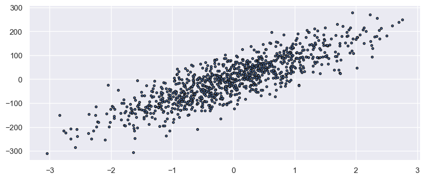

```python
# Génération d'un ensemble de données de régression avec make_regression de scikit-learn
# n_samples définit le nombre de points de données
# n_features définit le nombre de caractéristiques (variables indépendantes)
# n_informative définit le nombre de caractéristiques utiles pour la prédiction
# noise ajoute du bruit aux données pour simuler des variations
# random_state fixe la séquence de nombres aléatoires pour la reproductibilité
# Documentation scikit-learn pour make_regression: https://scikit-learn.org/stable/modules/generated/sklearn.datasets.make_regression.html
X, y = make_regression(n_samples=1000, n_features=1, n_informative=1, noise=50, random_state=0)

# Création d'un nuage de points (scatter plot) avec matplotlib
# Les points sont définis par les données générées X et y
# edgecolor='k' spécifie une bordure noire autour des points
# marker='.' spécifie que les points sont représentés par des points (petits cercles)
# Documentation matplotlib pour scatter: https://matplotlib.org/stable/api/_as_gen/matplotlib.pyplot.scatter.html
plt.scatter(X, y, edgecolor='k', marker='.')

# Création de deux DataFrames pandas à partir des données générées X et y
# Les colonnes sont nommées 'x' et 'y' respectivement
# Documentation pandas pour DataFrame: https://pandas.pydata.org/pandas-docs/stable/reference/api/pandas.DataFrame.html
x = pd.DataFrame(X, columns=['x'])
y = pd.DataFrame(y, columns=['y'])
```

```python
# Calcul de la corrélation de Pearson entre les colonnes 'x' et 'y' des DataFrames x et y
# Utilisation de la fonction pearsonr du module scipy.stats
# La fonction pearsonr renvoie un tuple contenant le coefficient de corrélation de Pearson et la valeur p associée
print("Pearson " + str(pearsonr(x.x, y.y)))

# Calcul de la corrélation de Kendall entre les colonnes 'x' et 'y' des DataFrames x et y
# Utilisation de la fonction kendalltau du module scipy.stats
# La fonction kendalltau renvoie un tuple contenant le coefficient de corrélation de Kendall et la valeur p associée
print(kendalltau(x.x, y.y))

# Calcul de la corrélation de Spearman entre les colonnes 'x' et 'y' des DataFrames x et y
# Utilisation de la fonction spearmanr du module scipy.stats
# La fonction spearmanr renvoie un tuple contenant le coefficient de corrélation de Spearman et la valeur p associée
print(spearmanr(x.x, y.y))
```

```
Pearson PearsonRResult(statistic=0.8522914621548177, pvalue=3.9071630180850793e-283)
SignificanceResult(statistic=0.650034034034034, pvalue=4.861439501213743e-208)
SignificanceResult(statistic=0.8403487803487804, pvalue=1.1110733387280784e-267)
```